# Lab One: CNN Visualization

Xingming Qu, Bowei Tian

## 1. Based on the blog post above, create and argue for one reason you might use DeepDream to analyze a CNN visually. Write out this argument in text for the lab using your own words. Alternatively, you can also argue for a counter argument (that is, why this is only artistic, not useful).

First I agree that DeepDream is useful to analyze a CNN visually.  
In DeepDream, an arbitrary image or photo will be analyze by the network. As showed in the blog, one can easily visualize intermediate activations by pick a layer and ask the network to enhance whatever it detected(ask the network which part of the image was actived).  
For exmaple, in the blog they used a blue sky picture as the input of the network. Becuase the network was trained mostly on images of animals, it then identified some parts of cloud and sky which resemble animals and made it more like animals. This shows the network really learned how to identified animals: Different filters learn to identify different features.  
Therefore, the way of DeepDream detects objects and makes them more obvious can be regard as a way to visualize intermediate activations.

## 2. In groups, you should select a convolutional neural network model that has been pre-trained on a large dataset (preferably, ImageNet). These already trained models are readily available online through many mechanisms, including the keras.application package (Inception, Xception, VGG etc.). Explain the model you chose and why.

In this lab, Xception will be used. Because Xception is the start-of-art model in Keras and I have never used this network. Besides, the model is only 88MB, which is smaller than VGG and Inceptionv3.

There were some DeepDream implemented by Keras. Reference:https://github.com/notabee/Deep_dream/blob/master/deep_dream_keras.ipynb (Inceptionv3)  
https://github.com/isarth/DeepDream/blob/master/deep%20dream2.ipynb (VGG16)  
https://github.com/google/deepdream/blob/master/dream.ipynb (Caffe inceptionv3 )

```python
from keras.applications import inception_v3
from keras.applications import xception
from keras import backend as K
from keras.preprocessing import image
import tensorflow as tf
from sklearn.datasets import load_sample_image
from keras.preprocessing import image
import warnings
import scipy
import numpy as np
import random
import cv2
from matplotlib import pyplot as plt
warnings.filterwarnings('ignore')
```

```python
# load the xception model
# model = inception_v3.InceptionV3( weights='imagenet', include_top=False )
model = xception.Xception( weights='imagenet', include_top=False )
model.summary()
```

```
__________________________________________________________________________________________________
Layer (type)                    Output Shape         Param #     Connected to
==================================================================================================
input_1 (InputLayer)            (None, None, None, 3 0
__________________________________________________________________________________________________
block1_conv1 (Conv2D)           (None, None, None, 3 864         input_1[0][0]
__________________________________________________________________________________________________
block1_conv1_bn (BatchNormaliza (None, None, None, 3 128         block1_conv1[0][0]
__________________________________________________________________________________________________
block1_conv1_act (Activation)   (None, None, None, 3 0           block1_conv1_bn[0][0]
__________________________________________________________________________________________________
block1_conv2 (Conv2D)           (None, None, None, 6 18432       block1_conv1_act[0][0]
__________________________________________________________________________________________________
block1_conv2_bn (BatchNormaliza (None, None, None, 6 256         block1_conv2[0][0]
__________________________________________________________________________________________________
block1_conv2_act (Activation)   (None, None, None, 6 0           block1_conv2_bn[0][0]
__________________________________________________________________________________________________
block2_sepconv1 (SeparableConv2 (None, None, None, 1 8768        block1_conv2_act[0][0]
__________________________________________________________________________________________________
block2_sepconv1_bn (BatchNormal (None, None, None, 1 512         block2_sepconv1[0][0]
__________________________________________________________________________________________________
block2_sepconv2_act (Activation (None, None, None, 1 0           block2_sepconv1_bn[0][0]
__________________________________________________________________________________________________
block2_sepconv2 (SeparableConv2 (None, None, None, 1 17536       block2_sepconv2_act[0][0]
__________________________________________________________________________________________________
block2_sepconv2_bn (BatchNormal (None, None, None, 1 512         block2_sepconv2[0][0]
__________________________________________________________________________________________________
conv2d_1 (Conv2D)               (None, None, None, 1 8192        block1_conv2_act[0][0]
__________________________________________________________________________________________________
block2_pool (MaxPooling2D)      (None, None, None, 1 0           block2_sepconv2_bn[0][0]
__________________________________________________________________________________________________
batch_normalization_1 (BatchNor (None, None, None, 1 512         conv2d_1[0][0]
__________________________________________________________________________________________________
add_1 (Add)                     (None, None, None, 1 0           block2_pool[0][0]
                                                                 batch_normalization_1[0][0]
__________________________________________________________________________________________________
block3_sepconv1_act (Activation (None, None, None, 1 0           add_1[0][0]
__________________________________________________________________________________________________
block3_sepconv1 (SeparableConv2 (None, None, None, 2 33920       block3_sepconv1_act[0][0]
__________________________________________________________________________________________________
```

[output cut: 228 more lines]

```
__________________________________________________________________________________________________
block14_sepconv1_bn (BatchNorma (None, None, None, 1 6144        block14_sepconv1[0][0]
__________________________________________________________________________________________________
block14_sepconv1_act (Activatio (None, None, None, 1 0           block14_sepconv1_bn[0][0]
__________________________________________________________________________________________________
block14_sepconv2 (SeparableConv (None, None, None, 2 3159552     block14_sepconv1_act[0][0]
__________________________________________________________________________________________________
block14_sepconv2_bn (BatchNorma (None, None, None, 2 8192        block14_sepconv2[0][0]
__________________________________________________________________________________________________
block14_sepconv2_act (Activatio (None, None, None, 2 0           block14_sepconv2_bn[0][0]
==================================================================================================
Total params: 20,861,480
Trainable params: 20,806,952
Non-trainable params: 54,528
__________________________________________________________________________________________________
```

```python
#conntribution of each layers activation coefficient
layer_contributions = {
    'block14_sepconv1': 0.5,
    'block14_sepconv2': 0.5,
    'block13_sepconv1': 1,
    'block13_sepconv2': 1,
    'block12_sepconv1': 1,
    'block12_sepconv2': 1,
    'block11_sepconv1': 1,
    'block10_sepconv1': 1,
    'conv2d_1': 2,
    'conv2d_2': 2,
    'conv2d_3': 2,
    'conv2d_4': 2,
    'block1_conv2': 3,
    'block1_conv1': 3,
}

# # inception
# layer_contributions = {
#     'mixed2': 0.2,
#     'mixed3': 3.,
#     'mixed4': 2.,
#     'mixed5': 1.5,
# }
```

```python
# some useful function
# preprocess function. This function load a image and convert it to array
# add a batch dimension, and do the preprocessing
def preprocess_image(image_path):
    img = image.load_img(image_path) #loading image
    img = image.img_to_array(img) #convert to array
    img = np.expand_dims(img, axis=0) # add batch dimensions
    img = xception.preprocess_input(img) # preprocessing
    return img

# for interation. we only need read the img once and then we just preprocess arr
def preprocess_arr(img):
    img = np.expand_dims(img, axis=0) # add batch dimensions
    img = xception.preprocess_input(img) # preprocessing
    return img

# deprocess function. This function is used to convert a tensor into a valid image
def deprocess_image(x):
    x = x.reshape((x.shape[1], x.shape[2], 3)) #reshaping to ( h,w,c )

    #deprocess
    x /= 2.
    x += 0.5
    x *= 255.

    #clipping value out if range ( 0,255 ) ie out RGB value range
    x = np.clip(x, 0, 255).astype('uint8')
    return x

# resize a image. This function is used for
def resize_img(img, size):
    img = np.copy(img)
    #ratios to multiply to image dimensions to resize
    factors = (1,
             float(size[0]/img.shape[1]),
             float(size[1]/img.shape[2]),
             1
            )
    #applying ratios using scipy
    return  scipy.ndimage.zoom(img, factors, order=1)

# Random shift function
# percent is how much you want shift
# eg percent= 0.1 means the img will be ramdom shift in x and y with 0-10%
def shift_img(img, percent):
    img = np.copy(img)
    #ratios to multiply to image dimensions to shift
    factors = (1,
             random.uniform(-percent, percent),
            random.uniform(-percent, percent),
             1
            )
    #applying ratios using scipy
    return  scipy.ndimage.shift(img, factors, order=1)

# this function is used for saving img at various steps
def save_img(img, fname):
    pil_img = deprocess_image(np.copy(img))
    scipy.misc.imsave(fname, pil_img)
```

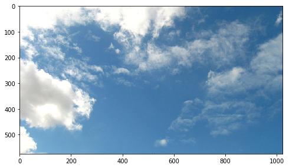

```python
#check preprocess and deprocess functions
image_path='sky1024px.jpg'
testimg=preprocess_image(image_path)
testimg=deprocess_image(testimg)

plt.figure(figsize=(8,12))
plt.imshow(testimg)
```

```python
#initial total weighted loss of the activations of the selected layers
def loss_init():
    loss = 0
    layer_dict = dict([layer.name, layer]for layer in model.layers) # making dictionary of layers and their instances

    for layer_name in  layer_contributions: # get coefficients and layer output
        coeff = layer_contributions[layer_name]  # get coefficients of the given layer

        activations = layer_dict[layer_name].output # get layer instance activations
        print('Layer:',layer_name,'    output shape:',activations.shape)

        #normalizing and clipping borders
        # When sum all the output from different layers,the loss will become very large
        # So we we need to normalize it
        scale = K.prod(K.cast(K.shape(activations), 'float32'))

        # K.shape: Returns the symbolic shape of a tensor or variable.
        # K.cast: Casts a tensor to a different dtype and returns it.
        # K.prod: Multiplies the values in a tensor, alongside the specified axis.
        # eg: d=np.array([[1,1,1],[2,3,4]])
        # prod(d)= 1*1*1*2*3*4=24

        # clipping borders
        # not including first two pixel border of the width and height
        # avoid border artifacts by only involving nonborder pixels in the loss.
        loss += coeff * K.sum(K.square(activations[: ,2:-2, 2:-2, :]))/scale # summation and normaliziation

    return loss
```

## 3. Manipulate the code from the CNN visualization notebook to implement the DeepDream process. This includes:

```python
loss = loss_init() #getting initial loss
dream = model.input #dream image to hold input
```

```
Layer: block14_sepconv1     output shape: (?, ?, ?, 1536)
Layer: block14_sepconv2     output shape: (?, ?, ?, 2048)
Layer: block13_sepconv1     output shape: (?, ?, ?, 728)
Layer: block13_sepconv2     output shape: (?, ?, ?, 1024)
Layer: block12_sepconv1     output shape: (?, ?, ?, 728)
Layer: block12_sepconv2     output shape: (?, ?, ?, 728)
Layer: block11_sepconv1     output shape: (?, ?, ?, 728)
Layer: block10_sepconv1     output shape: (?, ?, ?, 728)
Layer: conv2d_1     output shape: (?, ?, ?, 128)
Layer: conv2d_2     output shape: (?, ?, ?, 256)
Layer: conv2d_3     output shape: (?, ?, ?, 728)
Layer: conv2d_4     output shape: (?, ?, ?, 1024)
Layer: block1_conv2     output shape: (?, ?, ?, 64)
Layer: block1_conv1     output shape: (?, ?, ?, 32)
```

### 3.1 Using L1 gradient normalization for gradient updates

```python
# We take the gradient of this loss using keras backend.gradients
gradients = K.gradients(loss, dream)[0] # gradient of loss wrt to dream image

########   Using L1 gradient normalization for gradient updates    #######
# the shape of gradients should be (1,x,y,3)
# Before performing gradient ascent, we divide the gradient tensor by its L1 norm
# if this is the right way to caculate tensor's L1 norm:
# (the maximal number of the mean of the absolute values in the tensor).
# We add a small epsilon term to the L1 norm to avoid division by zero.
gradients /= np.max(K.mean(K.abs(gradients)))+1e-7 # normalizing gradients
# another way
# grads /= K.maximum(K.mean(K.abs(grads)), 1e-7)

########   Using L1 gradient normalization for gradient updates    #######

output = [loss, gradients] # making list of loss and grads
loss_and_grads = K.function([dream], output) #keras functions for input and output
```

```python
#getting loss and gradients wrt dream image
def fetch_loss_and_grad(img):
    outputs = loss_and_grads([img])
    return outputs[0], outputs[1]

#applying gradients on dream image via gradient ascent
# iter is run gradient ascent for xxx steps
def gradient_ascent(img, iter, step_alpha):
    for i in range(iter):
        loss, grads = fetch_loss_and_grad(img) #loading loss and grading with current state of dream image
        img += step_alpha * grads #adding gradients to dream image by multiplying with step_alpha similarly to gradient descent's alpha

    return img
```

### 3.2 Adding random shifts/resizing in the process (as described in DeepDream)

```python
def dream_maker( inputimg , step=0.01, octave = 3, octave_scale = 1.4, iter_times=20, addingshift=False):
    print('gradient_ascent_times:',iter_times)

    img = inputimg # inputimg should go through preprocessing

    original_shape = img.shape[1:3] #extracting ( h,w )
    #list of tuples---used for save different shapes
    succesive_shapes = [original_shape]

    #####    adding resizing in the process   #############
    for i in range(1,octave): #making reduced tuple of ( h,w )
        tuple_of_shapes = tuple([ int( shape/ (octave_scale ** i)) for shape in original_shape ])
        succesive_shapes.append( tuple_of_shapes )
    succesive_shapes = succesive_shapes[::-1] #reversing small to large

    original_img = np.copy(img) #copy image

    #####    Adding random shifts/resizing in the process   #############
    smallest_original_image = resize_img( original_img, succesive_shapes[0] ) #resizing original image to smallest octave
    if addingshift==True:
        smallest_original_image = shift_img(smallest_original_image,0.1)
    #####    Adding random shifts/resizing in the process   #############
    for shape in succesive_shapes:

        print('Processing image shape', shape)
        #####    Adding random shifts/resizing in the process   #############
        img  = resize_img( img  , shape) #resizing image to shape
        if addingshift==True:
            img  = shift_img( img  , 0.1)
        #####    Adding random shifts/resizing in the process   #############

        # run gradient ascent for xxx steps, and learning late is 0.01
        img = gradient_ascent( img, iter_times, 0.01) #applying gradient ascent on current current size of the image

        upscaled_smallest_original = resize_img( smallest_original_image, shape ) #getting original image of the current size
        downsized_original_image = resize_img( original_img, shape ) # reducing size of high resolution to current size

        details = downsized_original_image - upscaled_smallest_original # details we get after subtracting and these will be added to pixelated image

        img += details # adding lost details due to resizing


    return deprocess_image(img)
```

```
gradient_ascent_times: 80
Processing image shape (293, 522)
Processing image shape (410, 731)
Processing image shape (575, 1024)
```

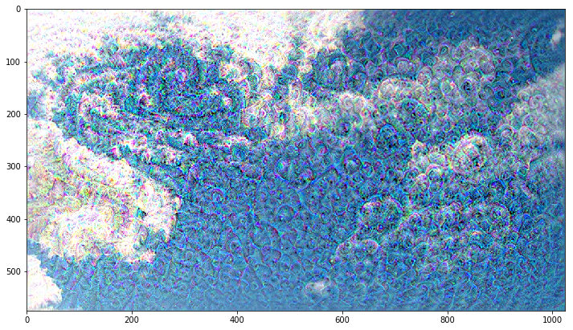

```python
## default is adding resizing in the process
re = dream_maker(preprocess_image(image_path), iter_times=80)
plt.figure(figsize=(12,18))
plt.imshow( re )
```

```
gradient_ascent_times: 80
Processing image shape (293, 522)
Processing image shape (410, 731)
Processing image shape (575, 1024)
```

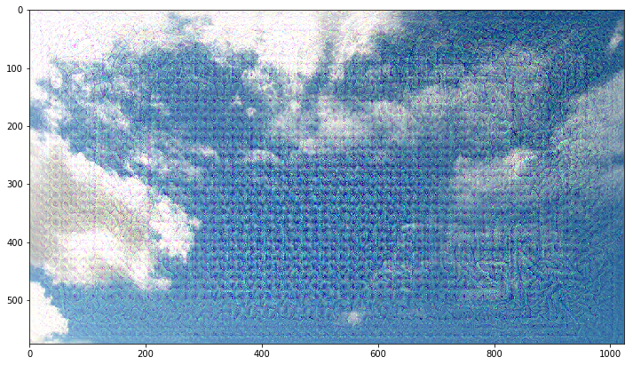

```python
# this time we adding random shifts to the image
re = dream_maker(preprocess_image(image_path), iter_times=80,addingshift=True)
plt.figure(figsize=(12,18))
plt.imshow(re)
```

### 3.3 If using code from another source, you must heavily document the code so that I can grade your understanding of the code used.

Enough comments have been added.

## 4. Choose an image to seed the DeepDream visualizations and run the DeepDream process. Save out the image at various steps so that you can visualize the iterative process (a video or GIF would be a nice addition).

```python
image_path='sky1024px.jpg'
test_img = image.load_img(image_path) #loading image
test_img = image.img_to_array(test_img) #convert to array
# Save out the image at various steps, in total 8 times
epoch=8
for i in range(epoch):
    if i==0:
        result = dream_maker(preprocess_arr(test_img), iter_times=5)
    else:
        result = dream_maker(preprocess_arr(result), iter_times=5)
    cv2.imwrite(str(i)+'.jpg',result[:,:,::-1])
```

```
gradient_ascent_times: 5
Processing image shape (293, 522)
Processing image shape (410, 731)
Processing image shape (575, 1024)
gradient_ascent_times: 5
Processing image shape (293, 522)
Processing image shape (410, 731)
Processing image shape (575, 1024)
gradient_ascent_times: 5
Processing image shape (293, 522)
Processing image shape (410, 731)
Processing image shape (575, 1024)
gradient_ascent_times: 5
Processing image shape (293, 522)
Processing image shape (410, 731)
Processing image shape (575, 1024)
gradient_ascent_times: 5
Processing image shape (293, 522)
Processing image shape (410, 731)
Processing image shape (575, 1024)
gradient_ascent_times: 5
Processing image shape (293, 522)
Processing image shape (410, 731)
Processing image shape (575, 1024)
gradient_ascent_times: 5
Processing image shape (293, 522)
Processing image shape (410, 731)
Processing image shape (575, 1024)
gradient_ascent_times: 5
Processing image shape (293, 522)
Processing image shape (410, 731)
Processing image shape (575, 1024)
```

```python
# after made gif in an online website....
def display_gif(fn):
    from IPython import display
    return display.HTML('<img src="{}">'.format(fn))
display_gif('result.gif')
```

[figure not shown]

### 4.1 Explain any clues that the iterative process gives for how the CNN discerns different classes, if any.

What we think is going on is that the raw images comes in for the first time and the neural network gives some high level abstraction and then goes into a feedback loop where it simply sees the higher level abstraction and adds more of it so that after 8 interations, you only see the high level abstractions and you loose the notion of the sky image.

## 5. Exceptional work: hypothesize another type of noise to introduce in the DeepDream process and implement it. Run the same image through as before and compare/contrast the result.

```python
############      Let's try add noise before DeepDream process ###################
############      add noise to the picture before perform DeepDream ##############
# In this task, we will use salt noise as an exmaple
from skimage.util import *
image_path='sky1024px.jpg'
original_ime=cv2.imread(image_path)
noiseimg=original_ime
noiseimg=random_noise(noiseimg, mode='salt',amount =0.03) #adding salt noise
# convert a tensor into a valid image
noiseimg=noiseimg*255
noiseimg = np.clip(noiseimg, 0, 255).astype('uint8')
# plt.figure(figsize=(8,12))
# plt.imshow(noiseimg[:,:,::-1] )
```

```python
Noise_re = dream_maker(preprocess_arr(noiseimg), iter_times=80)
origina_re = dream_maker(preprocess_arr(original_ime), iter_times=80)
```

```
gradient_ascent_times: 80
Processing image shape (293, 522)
Processing image shape (410, 731)
Processing image shape (575, 1024)
gradient_ascent_times: 80
Processing image shape (293, 522)
Processing image shape (410, 731)
Processing image shape (575, 1024)
```

```
Text(0.5,1,'Noise img after DeepDream')
```

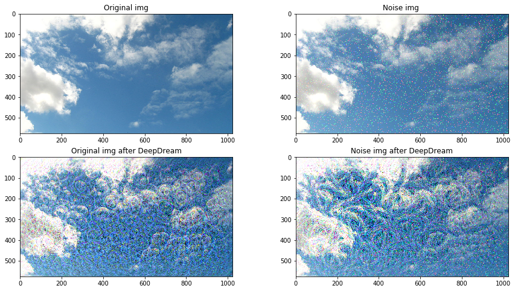

```python
plt.figure(figsize=(15,8))
plt.subplot(2,2,1)
plt.imshow( original_ime[:,:,::-1] )
plt.title('Original img')

plt.subplot(2,2,2)
plt.imshow( noiseimg[:,:,::-1] )
plt.title('Noise img ')

plt.subplot(2,2,3)
plt.imshow( origina_re[:,:,::-1] )
plt.title('Original img after DeepDream')

plt.subplot(2,2,4)
plt.imshow( Noise_re[:,:,::-1] )
plt.title('Noise img after DeepDream')
```

Looks like the original images after deap dream, the filters tend to super impose circular dog faces since we choose a lot of higher level layers we tend to see more complex features and the more abstract the neurons are capturing the concept, that doesnt mean it understands what is seeing but it does statistical matching to pick up the neurons doing the same type of thing and it's more tangible than edge detection early on.

I think the two images are different. Adding noise to the picture at begining will make the DeepDream effects more significant at the noise positions.

And what a surprise, the pattern of deepdream also changed!

```python
# Let's try introduce new noise in the DeepDream process
def dream_maker_with_noise( inputimg , step=0.01, octave = 3, octave_scale = 1.4, iter_times=20):
    print('gradient_ascent_times:',iter_times)

    img = inputimg # inputimg should go through preprocessing

    original_shape = img.shape[1:3] #extracting ( h,w )
    #list of tuples---used for save different shapes
    succesive_shapes = [original_shape]

    #####    adding resizing in the process   #############
    for i in range(1,octave): #making reduced tuple of ( h,w )
        tuple_of_shapes = tuple([ int( shape/ (octave_scale ** i)) for shape in original_shape ])
        succesive_shapes.append( tuple_of_shapes )
    succesive_shapes = succesive_shapes[::-1] #reversing small to large

    original_img = np.copy(img) #copy image

    #####    Adding random noise/resizing in the process   #############
    smallest_original_image = resize_img( original_img, succesive_shapes[0] ) #resizing original image to smallest octave

    smallest_original_image=random_noise(smallest_original_image, mode='salt',amount =0.03) #adding salt noise
    #####    Adding random noise/resizing in the process   #############
    for shape in succesive_shapes:

        print('Processing image shape', shape)
        #####    Adding random shifts/resizing in the process   #############
        img  = resize_img( img  , shape) #resizing image to shape

        img=random_noise(img, mode='salt',amount =0.03) #adding salt noise
        #####    Adding random shifts/resizing in the process   #############

        # run gradient ascent for xxx steps, and learning late is 0.01
        img = gradient_ascent( img, iter_times, 0.01) #applying gradient ascent on current current size of the image

        upscaled_smallest_original = resize_img( smallest_original_image, shape ) #getting original image of the current size
        #####    Adding random noise/resizing in the process   #############
        upscaled_smallest_original=random_noise(upscaled_smallest_original, mode='salt',amount =0.03) #adding salt noise
        downsized_original_image = resize_img( original_img, shape ) # reducing size of high resolution to current size
        #####    Adding random noise/resizing in the process   #############
        downsized_original_image=random_noise(downsized_original_image, mode='salt',amount =0.03)
        details = downsized_original_image - upscaled_smallest_original # details we get after subtracting and these will be added to pixelated image

        img += details # adding lost details due to resizing


    return deprocess_image(img)
```

```python
add_Noise_inprocess_re = dream_maker_with_noise(preprocess_arr(original_ime), iter_times=80)
```

```
gradient_ascent_times: 80
Processing image shape (293, 522)
Processing image shape (410, 731)
Processing image shape (575, 1024)
```

```
Text(0.5,1,'Add Salt Noise in process')
```

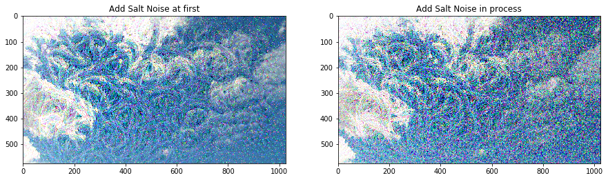

```python
plt.figure(figsize=(15,8))
plt.subplot(1,2,1)
plt.imshow( Noise_re[:,:,::-1] )
plt.title('Add Salt Noise at first')


plt.subplot(1,2,2)
plt.imshow( add_Noise_inprocess_re[:,:,::-1] )
plt.title('Add Salt Noise in process')
```

I think the result of adding salt noise only once at first is better than adding salt Noise in process. Adding more noise in the process does not make the image more beautiful but makes it more unclear. Their pattern still seems similar.